# Systematic Map database description

Devi Veytia

2023-06-26

# Background

Here I present the preliminary predictions from the machine learning model for (1) relevance, and (2) metadata coding.

To achieve this, first we used our search string to retrieve a literature from two citation indexed databases: Web of Science and Scopus. These articles were then de-duplicated based on title and year matching.

From this de-duplicated corpus, a subset of articles were screened for inclusion or exclusion, with the following results:

| Screening decision | Number of articles |
| --- | --- |
| exclude | 1796 |
| include | 956 |

To generate predicted relevance for all “unseen” articles, a machine learning binary classification model was trained and tested on the “seen” corpus summarized above (see “Screening” section). The model generates a prediction of relevance – a value between 0 and 1, with 1 being relevant and 0 being irrelevant. Estimates for the mean, lower (mean - 1 std) and upper (mean + 1 std) are also generated. Following the approach of Callaghan et al 2021, we use the upper estimate for the relevance predictions which is the most conservative. A value of greater or equal to 0.5 would be considered an inclusion.

The articles that were labelled as inclusions from the screened subset above were then coded for metadata variables. For each variable, the labels decided by a human were used to train multi-label or binary classifiers (using the former if the variable allowed multiple choice values) analagous to the method used above(see “Coding” section).

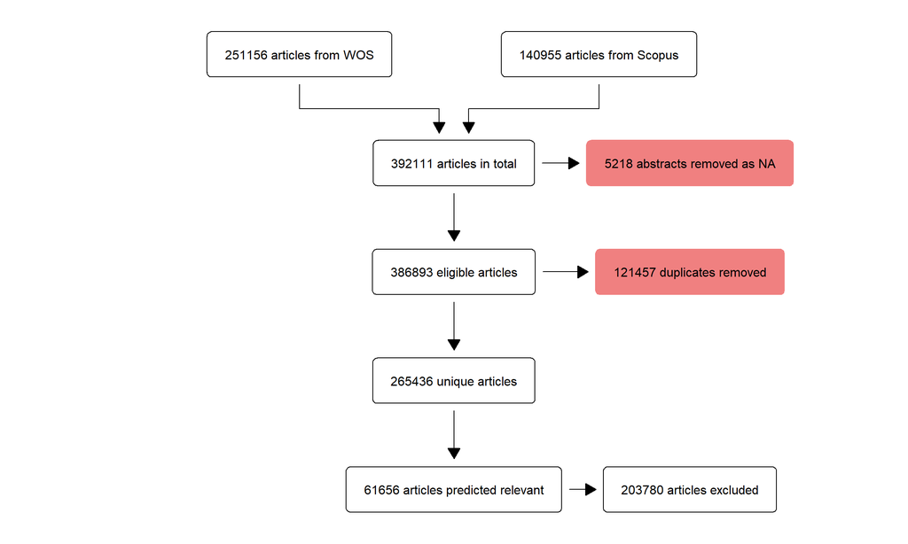

PRISMA diagram of the corpus

# Screening

In total, the model predicts the following numbers of relevant articles for the mean +/- 1 standard deviation:

| lower | mean | upper |
| --- | --- | --- |
| 32578 | 44193 | 61656 |

To dig further, a lot of information about model performance can be gained by comparing the distribution of predicted relevance to screening decisions made by human reviewers (binary outcome = inclusion vs exclusion). Ideally, high predicted relevance will be seen for articles which were included, and vice versa.

Of the test list articles (our list of benchmark/exemplary articles), was was the predicted relevance? Overall, both mean and upper estimate (+1 standard deviation) demonstrate 100% recall for the test list articles (i.e. no false negatives).

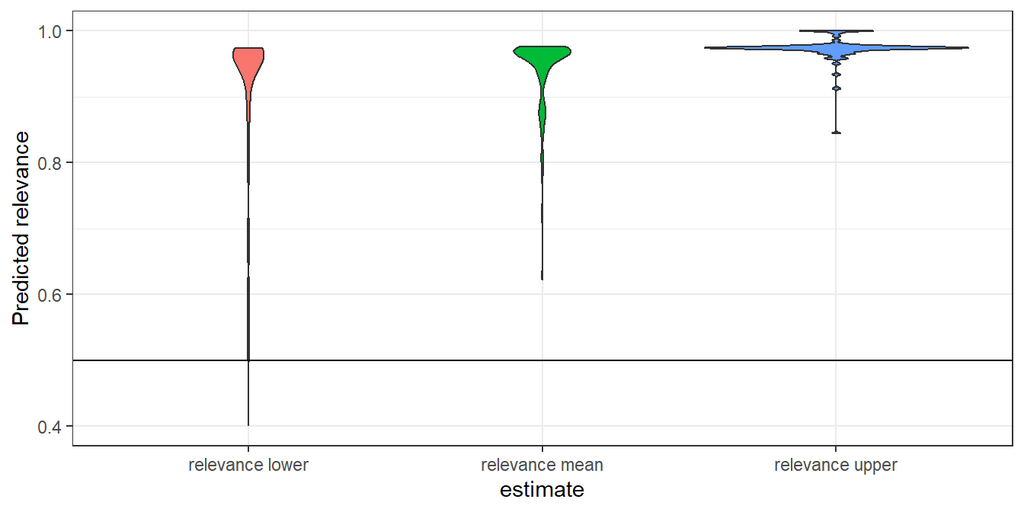

predicted relevance for test list articles

This can be extended to all the articles screened, not just the test list articles. The red text labels show the counts of articles which fall into each possible outcome with a binary classification (true positive, false positive, true negative, false negative). Overall the model performs fairly well with high accuracy by predicting true positives and true negatives. While taking the upper limit minimizes the number of false negatives, it also performs more poorly on precision (more false positives).

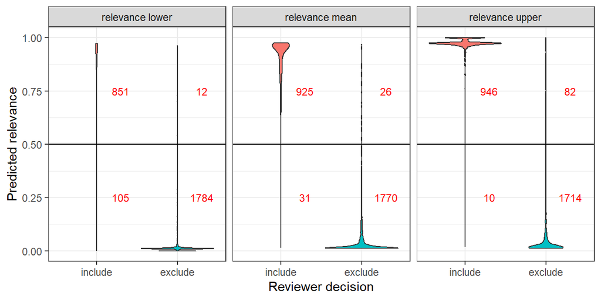

The distribution of predicted relevance for all articles screened by model estimate

# Coding

This section will summarise and visualize the model predictions for each of the variables coded so far. At the end of the section will be a summary table providing the article counts (i.e. number of articles predicted relevant) for each variable.

## ORO Branch

Since our ORO typology is hierarchical (see below), an incremental approach was taken to predict the type of ORO mentioned in the abstract. First the “branch” of the ORO was predicted (i.e. Mitigation, Natural resilience and Societal adaptation). Given the branch predicted (e.g. Societal), then the more granular type of ORO was predicted (Socio-institutional or Built infrastructure).

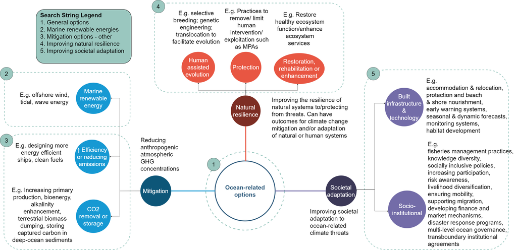

Firstly, of all the articles predicted relevant at the screeing stage, how many articles are predicted to be relevant for each ORO branch? Note the unclear option is chosen for any article included at the screening stage, but without a relevance prediction for any particular branch.

| ORO_branch | n_articles |
| --- | --- |
| Mitigation_upper | 50208 |
| Nature_upper | 7921 |
| Societal_upper | 5604 |
| Unclear | 876 |

We can next look at which branches were predicted to be relevant, compared to what branch was selected:

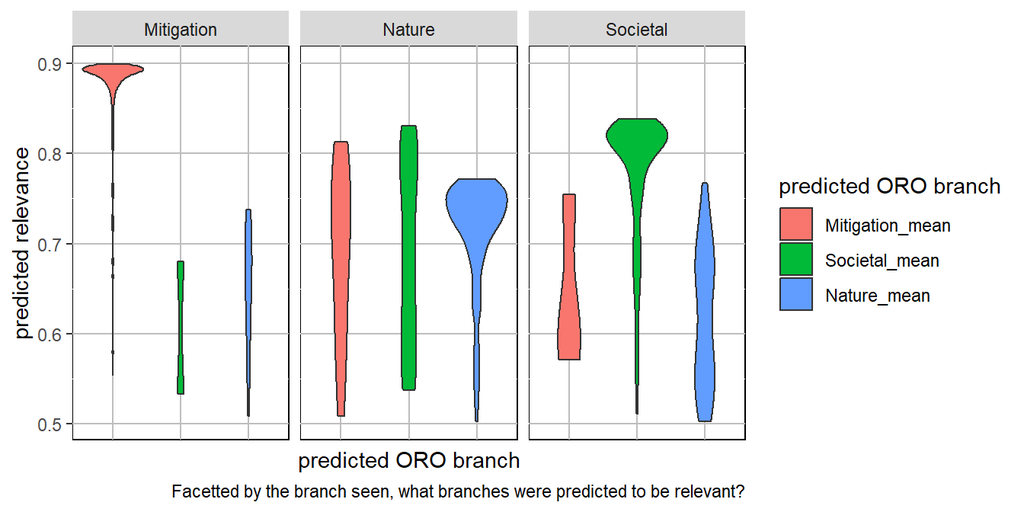

facetted by the branch seen, which branches were predicted relevant?

## ORO type

Next, looking at the more granular typology of ORO type, we can first ask “How many articles (over the whole relevant corpus) are predicted relevant for each ORO type?”

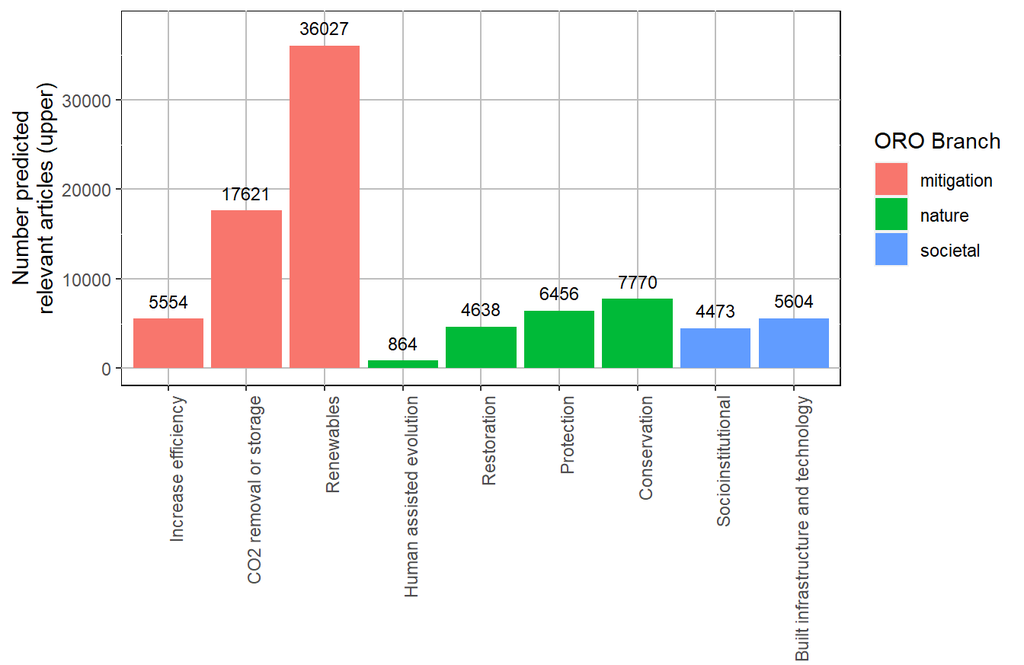

number of articles relevant to each ORO type

We may also want to ask, how many articles contain predicted relevance for more than one ORO type, and which types display the most linkages? Note in the figure that the pink rectangle identifies inter-branch interactions between mitigation and natural resilience, the purple between mitigation and societal, and the green between societal adaptation and natural resilience.

These inter-branch interactions occur most often between Conservation options (Protection and Restoration) and CO2 removal and storage, as well as with societal adaptation options. However, recalling evaluating the predictions for ORO type against the known values, both mitigation and societal branches tended to also be predicted as relevant for Natural resilience options. So it is difficult to discern if this is a true phenomenon or just a result of the overlapping language and objectives across these options. It is likely the latter, as objectives for both mitigation and societal adaptation can often motivate nature-based solutions and adaptation options.

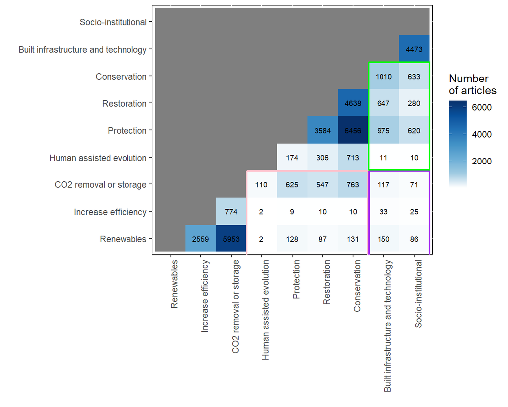

Interlinkages between ORO types

From the figures above, we can see an additional category added under the Natural resilience ORO branch: Conservation. This was trialed as a union between Protection and/or Restoration, as often in the literature these options are used together as a broader conservation portfolio and may be difficult to distinguish. Here I compare the performance of these three labels (protection, restoration and conservation) against the decisions from the seen articles.

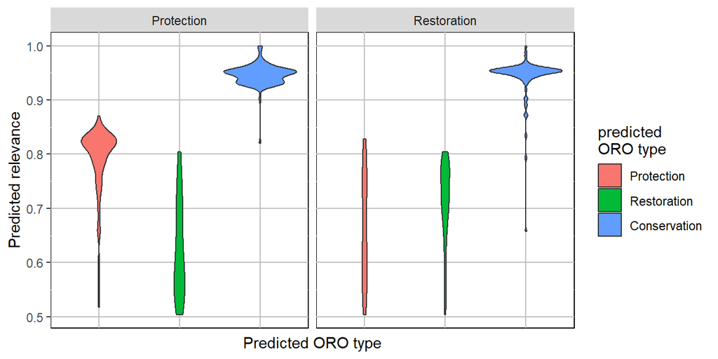

This indicates that for protection OROs, the model predicts a higher protection relevance than restoration, however the reverse is not true for restoration. Conservation is consistently high for both.

Extending this analysis to all the types of OROs (not including the Conservation label), this yeilds the following figure. Note that each panel refers to the ORO type that was chosen by the reviewer.

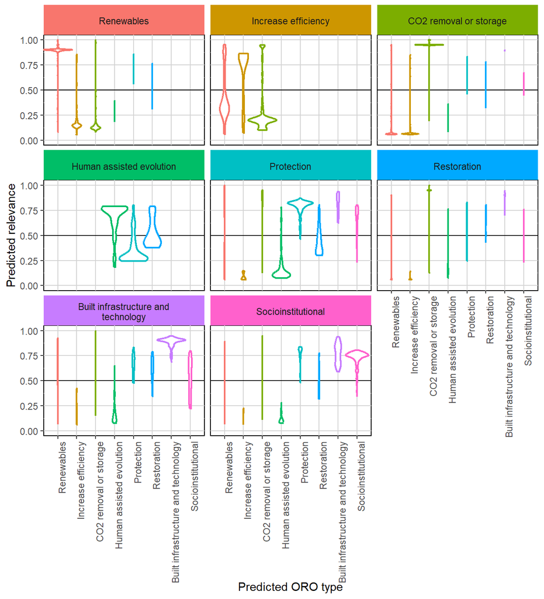

facetted by the oro type seen, which were predicted relevant?

## Product-specific variables

### Product 2: biodiversity_metric and impact_nature

While neither of these variables received good F1 scores, we can still compare the predicted relevance with the coded answers.

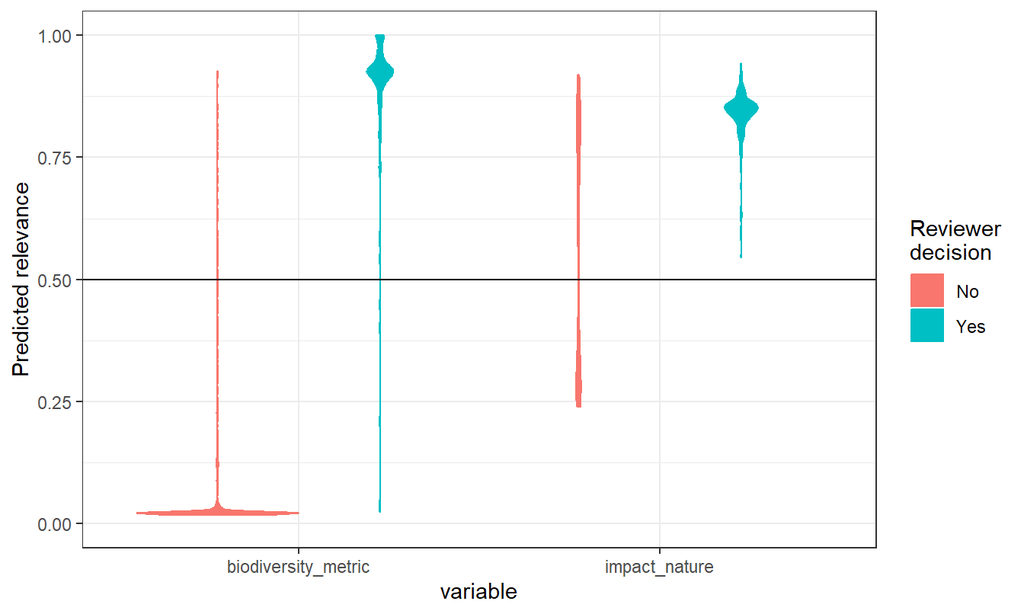

However, looking at the distributions, we could attain better precision by increasing the threshold for predicted inclusion.

Which “threshold” would yield the best F1 ratio (harmonic mean of precision and recall)? Note that these F1 ratios do not reflect the “true” values obtained through model selection, because these were calculated from all the seen data, rather than across different folds.

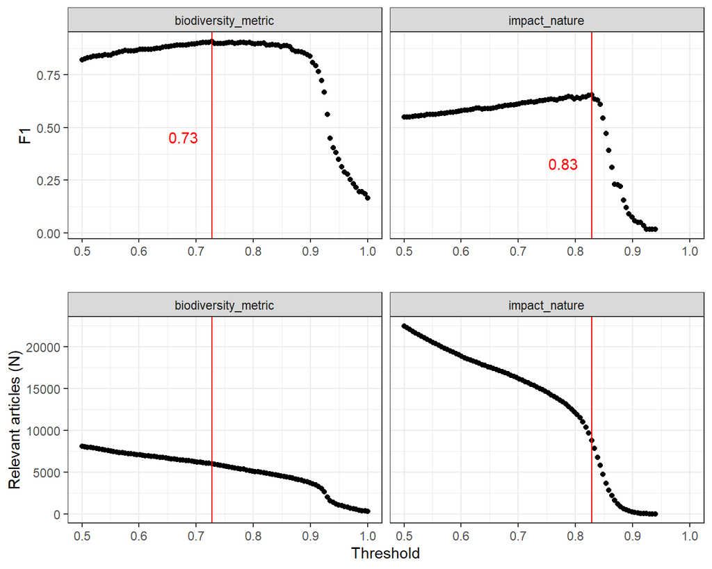

If we then apply these thresholds, how many articles are predicted relevant across the entire corpus? Note here the thresholds are rounded to the nearest digit. I.e. 0.73 -> 0.7.

| variable | threshold | n_articles_upper |
| --- | --- | --- |
| biodiversity_metric_relevant | 0.7 | 6237 |
| impact_nature_relevant | 0.8 | 12090 |

### Product 3: restoration

Compare the predicted relevance with the coded answers.

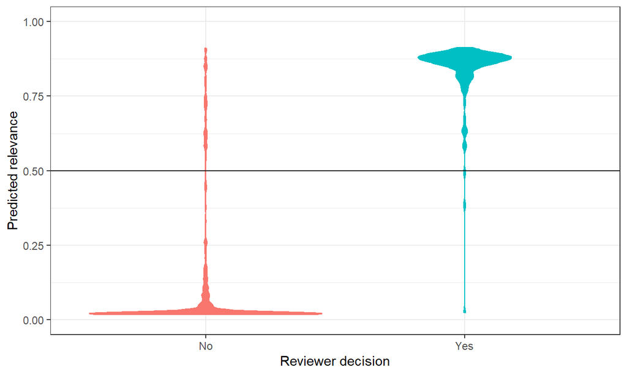

### Product 4: safe_fish and safe_space

While neither of these variables received good F1 scores, we can still compare the predicted relevance with the codded answers.

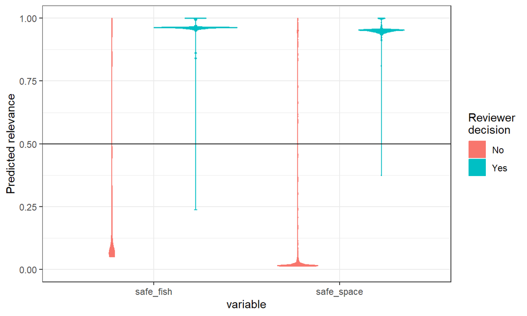

## Summary: Tabulation of articles across all variables

The following table provides the number of articles predicted to be relevant for each category. Categories are defined by the columns “variable” and “label”. Note that for each variable, multiple labels can be selected for one article. The number of articles is derived using the upper estimate of predicted relevance.

These tabulations are also saved in the file titled “codingTabulations.xlsx”

| variable | label | n_articles_upper |
| --- | --- | --- |
| oro_branch | Mitigation | 50208 |
| oro_branch | Nature | 7921 |
| oro_branch | Societal | 5604 |
| oro_branch | Unclear | 876 |
| oro_type | Increase_efficiency | 5554 |
| oro_type | CO2_removal_or_storage | 17621 |
| oro_type | Renewables | 36027 |
| oro_type | Human_assisted_evolution | 864 |
| oro_type | Restoration | 4638 |
| oro_type | Protection | 6456 |
| oro_type | Conservation | 7770 |
| oro_type | Socioinstitutional | 4473 |
| oro_type | Built_infrastructure_and_technology | 5604 |
| biodiversity_metric | include | 6237 |
| impact_nature | include | 12090 |
| restoration | include | 5987 |
| safe_fish | include | 6509 |
| safe_space | include | 7460 |

# README: Information about the dataset

All files are formatted as tab-delimited .txt files, so that commas and punctuation appearing in the free text columns (e.g. abstract) do not mess up the allocations of cells.

Each file contains a different componenet of information from different stages of the analysis (described below), and each can be joined by the following common ID column:

analysis_id = A unique identifier for each publiction retrieved by the search strategy Each dataset

**Dataset 1.1: screeningDecisions.txt**

This file contains the screening decisions for each article that was coded manually to train the data.

The columns include: reviewer = the name of the first reviewer reviewer_2 = the name of the second reviewer if the article underwent a double-blind check. test_list = will equal “test list” if the article was a part of the test list or “NA” if not include_screen = a binary value of 0 or 1, 1 indicating the article was included

**Dataset 1.2: codingDecisions.txt**

This file contains the coding decisions for each article that was coded manually to train the data. Descriptions for the different variables and values can be found in the “variableDescriptions.xlsx” file.

The columns include: coder_1 = the name of the first coder coder_2 = the name of the second coder if the article was coded twice for a consistency check.

The rest of the columns follow the following nomenclature: [name of variable].[name of value] Note that multiple values can be selected for each variable. A value of 1 indicates a selection, while 0 indicates absence.

**Dataset 2: deduplicatedCorpus.txt**

This file contains the de-duplicated corpus of literature that is used for deriving predictions from the model once it is trained.

The additional columns include:

duplicate_id = A unique identifier for each unit of publication (i.e. after de-duplication). n_duplicates = the number of articles which were assigned to the same duplicate_id title = the title of the article abstract = the abstract of the article keywords = the keywords of the article year = the year of publication doi = the DOI of the article if available source_title = the title of the source of the publication (e.g. journal name)

**Dataset 3: upperPredictions.txt**

This file contains the predictions (using the upper estimate) of the machine learning model for the screening and coded variables. The column names for the variables and values adopt the same naming convention used in the codingDecisions.txt file. However, instead of a binary value of 0 or 1 for exclusion vs inclusion, the column will contain a continuous value from 0 to 1 indicating the degree of relevance. Columns with predicted relevance greater or equal to 0.5 are classified as a relevant response.

the suffix “_upper” on the column names indicates that it is the upper estimate of predicted relevance